# Roulette Analysis

Fisher Ankney

8/09/2018

### Introduction

Recently, I rewatched the classic 1971 western *Support your Local Gunfighter*. Throughout the movie, a signature bet of 23-black is placed on a game of roulette. While the cast of played out gun fights and roulette spins, I began to devise this simple roulette anaylsis in R.

Roulette is a simple game of chance; a ball is dropped onto a wheel with 38 slots for it to land. The slots are numbered 0 to 36, with a 00 thrown in to further the odds in the casino’s favor. The 0 and 00 slots are green, while the 36 numbered slots are split evenly between black and red. For more informatin on how roulette is played, check out this video.

By creating a sample of 10,000 roulette spins and running a simulation with these three gambling strategies, I will evaluate how each gambler performs at defined intervals. The number of wins and total earnings of each gambler, how these trends change over time, and the occurances and duration of *dry streaks* are all of interest in this simulation.

### Libraries

The only library needed to complete this study is the tidyverse set of packages.

```r
library('tidyverse')
```

### Simulation

I’ve created a script to simulate 10,000 roulette spins as a separate file. The files have been separated like this because I want to work with a single, consistant simulation. The script loads the tidyverse library, then creates a data structure saving 10,000 elements containing a randomly chosen number between -1 and 36. In this simulation, -1 acts as 00. Each of these element are individually generated, and are not affected by the preceding sample. The data structure is saved as a .csv file and loaded into this study.

```r
# A copy of the roulette.csv file
library('tidyverse')

roulette <- as_tibble(sample(-1:36, 10000, replace=T))
write_csv(roulette, "roulette.csv")
```

```r
# loading roulette.csv
roulette <- read_csv("roulette.csv")
roulette <- as.integer(roulette$value)
```

Before analyzing the three gambling styles, we must define them. Gambler A always bets on black, Gambler B always bets the third dozen, and Gambler C always bets on lucky number 23.

```r
# The Gamblers Bets
black <- c(2, 4, 7, 8, 10, 11, 13, 15, 17, 20, 22, 24, 26, 28, 29, 31, 33, 35)
third_dozen <- c(25, 26, 27, 28, 29, 30, 31, 32, 33, 34, 35, 36)
lucky_23 <- 23
```

The next step is to create a series of data structures to record how each gambling strategy performs throughout the simulation. A vector to record cash is created for each of the three strategies. Cash records the cumulative earnings (or losings) for each of the 10,000 spins. At the end of every spin, a singular variable, *total cash* is saved for each of the three gamblers. Total cash is copied to an element of the cash vector, thus saving it’s value for each of the 10,000 spins.

A similiar process is used for keeping track of each gamblers wins. A wins vector is created continuously record the number of wins throughout the simulation. A single variable, total wins, is updated and copied to an element of the wins vector for each spin.

This system is repeated three times in order to keep track of all three gamblers running winnings, cumulative winnings, running earnings, and cumulative earnings.

```r
# Initialize gambler A
ga_earn <- vector("double", length(roulette))
ga_total_earn <- 0
ga_wins <- vector("double", length(roulette))
ga_total_wins <- 0

# Initialize gambler B
gb_earn <- vector("double", length(roulette))
gb_total_earn <- 0
gb_wins <- vector("double", length(roulette))
gb_total_wins <- 0

# Initialize gambler C
gc_earn <- vector("double", length(roulette))
gc_total_earn <- 0
gc_wins <- vector("double", length(roulette))
gc_total_wins <- 0
```

Now we can analyze the roulette spins. For each element in the sequence of 10,000 spins saved in the variable `roulette`, the following occurs. Ten dollars is taken from each of the gamblers total winnings as their bets. The new total winnings amount is saved over the old winnings. If the number inside of the roulette element falls within the previously defined `black` bet, gambler a wins. When gambler A wins, gambler A’s total cash is increased by $20 and their total wins are increased by 1. Gamblers B and C go through similiar if - then statements, eaching recieving winnings according to the payout of their specific bets. After all of the gamblers bets have been analyzed, the new total earnings and wins are saved into an empty element in the running cash and wins matrices.

The running wins and earnings matrices are the key to exploring each of the gamblings stragies in this simulation.

```r
for (i in seq_along(roulette)) {
# All gamblers bet $10
  ga_total_earn = ga_total_earn - 10
  gb_total_earn = gb_total_earn - 10
  gc_total_earn = gc_total_earn - 10
# If gambler A wins, +$20 and +1 win
  if (roulette[[i]] %in% black) {
    ga_total_earn = ga_total_earn + 20
    ga_total_wins = ga_total_wins + 1
  }
# If gambler B wins, +$30 and +1 win
  if (roulette[[i]] %in% third_dozen) {
    gb_total_earn = gb_total_earn + 30
    gb_total_wins = gb_total_wins + 1
  }
# If gambler C wins, +$360 and +1 win
  if (roulette[[i]] == lucky_23) {
    gc_total_earn = gc_total_earn + 360
    gc_total_wins = gc_total_wins + 1
  }
# End of round - save totals
  ga_earn[[i]] <- ga_total_earn
  ga_wins[[i]] <- ga_total_wins
  gb_earn[[i]] <- gb_total_earn
  gb_wins[[i]] <- gb_total_wins
  gc_earn[[i]] <- gc_total_earn
  gc_wins[[i]] <- gc_total_wins
}
```

### Storing Results

Before we jump into the wins and cash data structures, lets going to quickly plot up the 10,000 roulette spins to see if we can spot any unwanted patterns. The roulette spin results should all be random numbers between -1 and 36, independent of each other.

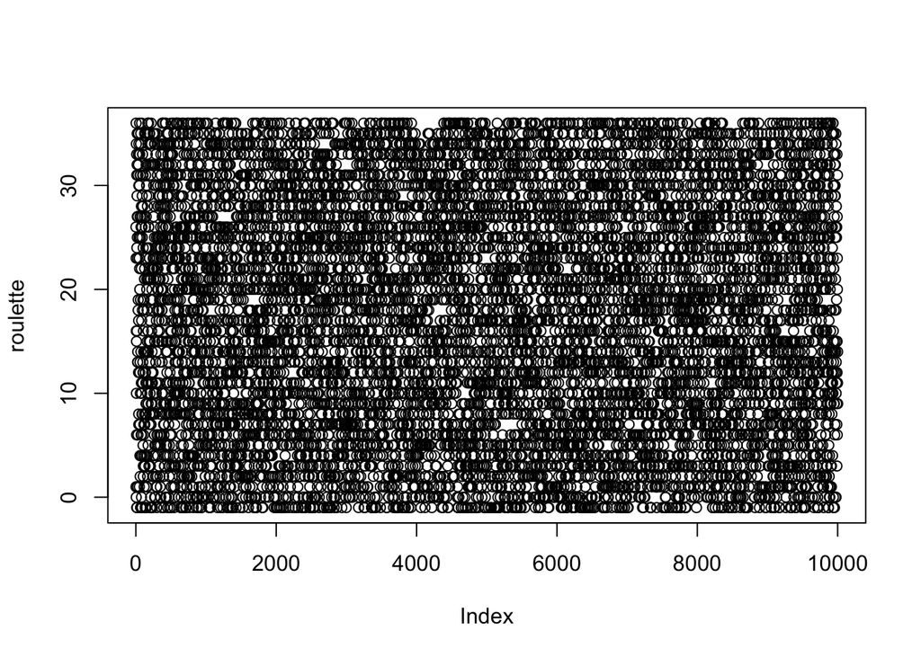

```r
plot(roulette)
```

The spread looks pretty random, let’s go ahead and sort the data into magnitudes and name each variable.

```r
# Define each gambler as a variable
ga <- "Gambler A"
gb <- "Gambler B"
gc <- "Gambler C"

# Break up the simulation into the defined magnitude intervals
results <- tibble(spin_num = 1:10000, ga, ga_earn, ga_wins, gb, gb_earn, gb_wins, gc, gc_earn, gc_wins)
results_100 <- head(results, n=100)
results_1000 <- head(results, n=1000)
```

### Earnings

We’ll analyze the roulette strategies at three different magnitudes. First we’ll take a look at trends within the first 100 spins, `results_100`, then we’ll look at the first 1000 spins, `results_1000`, and finally all 10,000 spins, `results`.

Let’s take a look at how many times each of the gamblers won their roulette bet in the first 100 spins.

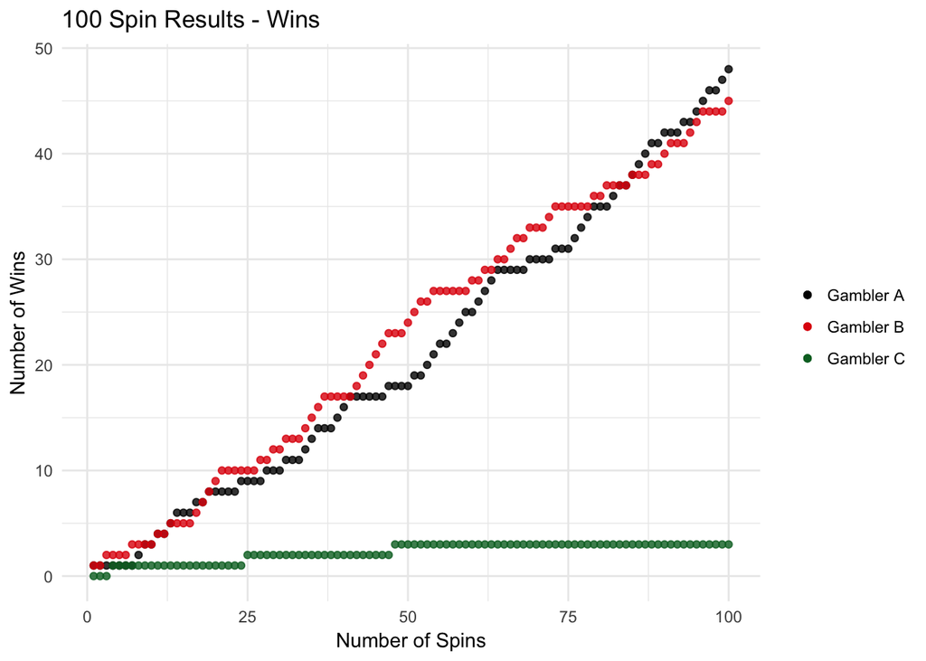

```r
ggplot(results_100) +
  geom_point(aes(x = spin_num, y = ga_wins, color = ga), alpha = 0.8) +
  geom_point(aes(x = spin_num, y = gb_wins, color = gb), alpha = 0.8) +
  geom_point(aes(x = spin_num, y  = gc_wins, color = gc), alpha = 0.8) +
  theme_minimal() +
  theme(legend.title=element_blank()) +
  scale_colour_manual(values = c("black", "#E0080B", "#016D29")) +
    labs(title = "100 Spin Results - Wins",
       y = "Number of Wins",
       x = "Number of Spins"
       )
```

If it isn’t clear by the graph, here’s the each of the gambler’s running totals at spin 100.

```r
ga_wins[100]
```

```
## [1] 48
```

```r
gb_wins[100]
```

```
## [1] 45
```

```r
gc_wins[100]
```

```
## [1] 3
```

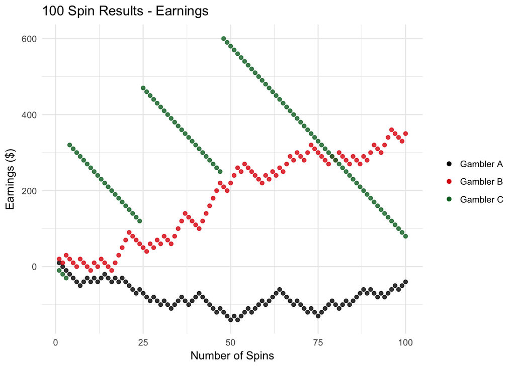

```r
ggplot(results_100) +
  geom_point(aes(x = spin_num, y = ga_earn, color = ga), alpha = 0.8) +
  geom_point(aes(x = spin_num, y = gb_earn, color = gb), alpha = 0.8) +
  geom_point(aes(x = spin_num, y = gc_earn, color = gc), alpha = 0.8) +
  theme_minimal() +
  theme(legend.title=element_blank()) +
  scale_colour_manual(values = c("black", "#E0080B", "#016D29")) +
    labs(title = "100 Spin Results - Earnings",
       y = "Earnings ($)",
       x = "Number of Spins"
       )
```

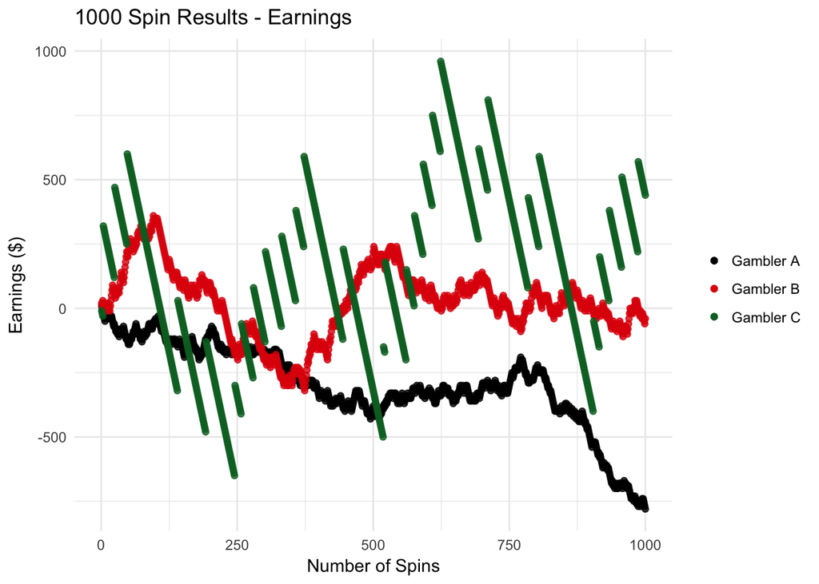

```r
ggplot(results_1000) +
  geom_point(aes(x = spin_num, y = ga_earn, color = ga), alpha = 0.8) +
  geom_point(aes(x = spin_num, y = gb_earn, color = gb), alpha = 0.8) +
  geom_point(aes(x = spin_num, y  = gc_earn, color = gc), alpha = 0.8) +
  theme_minimal() +
  theme(legend.title=element_blank()) +
  scale_colour_manual(values = c("black", "#E0080B", "#016D29")) +
    labs(title = "1000 Spin Results - Earnings",
       y = "Earnings ($)",
       x = "Number of Spins"
       )
```

Increasing the sample size by another magnitude tells us another story once again. Gambler C’s luck doesn’t hold out, and his earnings plummet lower than both Gambler A and Gambler B.

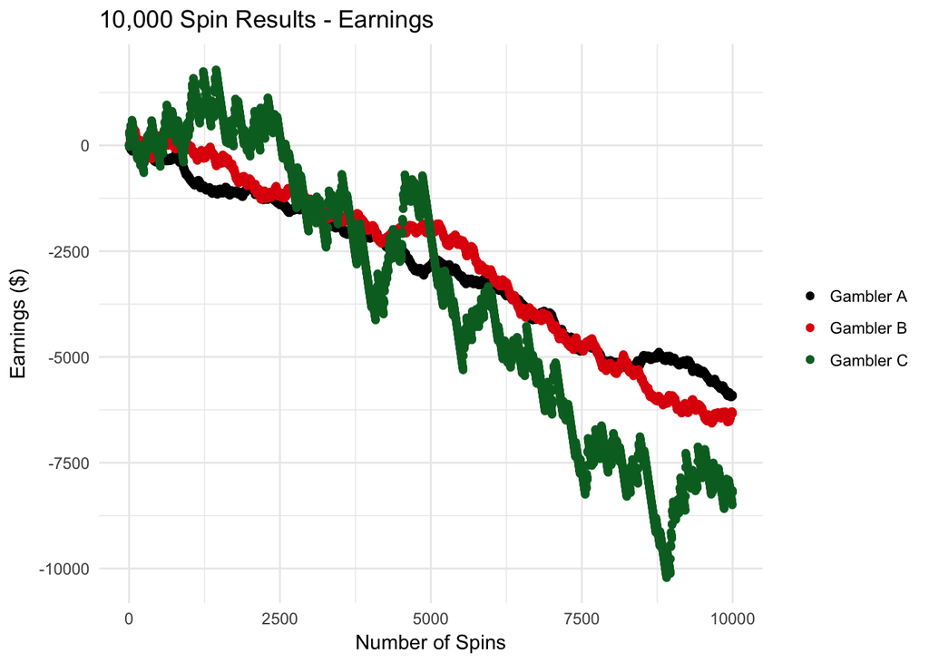

```r
ggplot(results) +
  geom_point(aes(x = spin_num, y = ga_earn, color = ga), alpha = 0.8) +
  geom_point(aes(x = spin_num, y = gb_earn, color = gb), alpha = 0.8) +
  geom_point(aes(x = spin_num, y  = gc_earn, color = gc), alpha = 0.8) +
  theme_minimal() +
  theme(legend.title=element_blank()) +
  scale_colour_manual(values = c("black", "#E0080B", "#016D29")) +
    labs(title = "10,000 Spin Results - Earnings",
       y = "Earnings ($)",
       x = "Number of Spins"
       )
```

### Wins

The number of wins each gambler experiences in 10,000 games is fairly predictable.

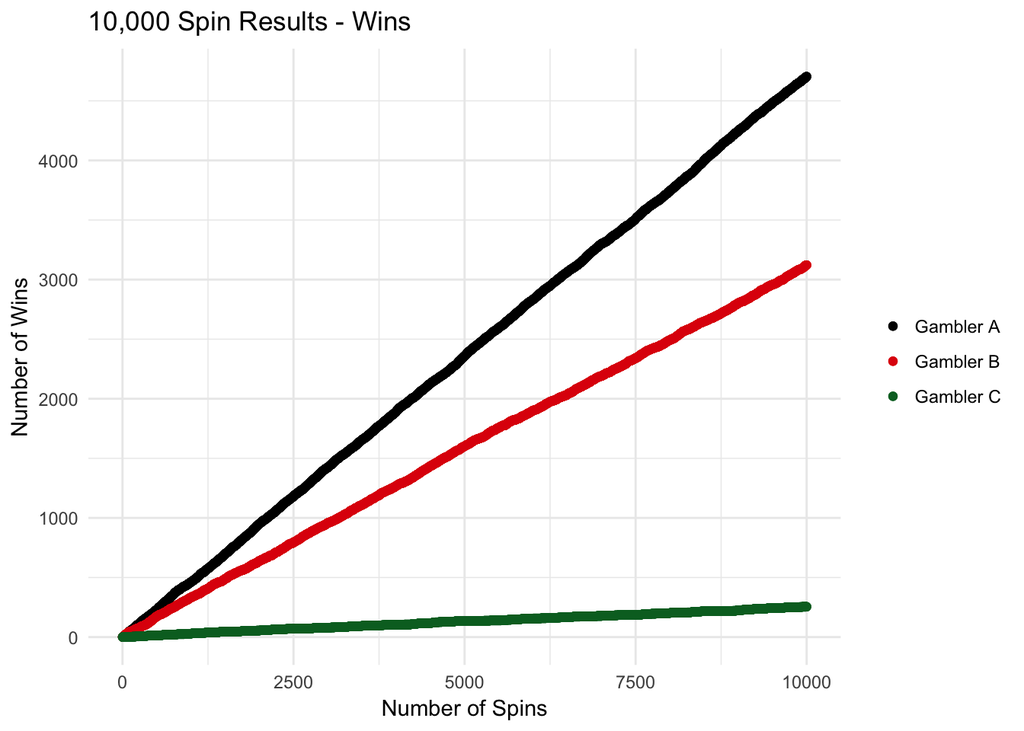

```r
ggplot(results) +
  geom_point(aes(x = spin_num, y = ga_wins, color = ga), alpha = 0.8) +
  geom_point(aes(x = spin_num, y = gb_wins, color = gb), alpha = 0.8) +
  geom_point(aes(x = spin_num, y  = gc_wins, color = gc), alpha = 0.8) +
  theme_minimal() +
  theme(legend.title=element_blank()) +
  scale_colour_manual(values = c("black", "#E0080B", "#016D29")) +
    labs(title = "10,000 Spin Results - Wins",
       y = "Number of Wins",
       x = "Number of Spins"
       )
```

After 10,000 spins, each gambler’s wins approach their bet’s probabilities.

```r
ga_total_wins / 10000 * 100
```

```
## [1] 47.04
```

```r
gb_total_wins / 10000 * 100
```

```
## [1] 31.22
```

```r
gc_total_wins / 10000 * 100
```

```
## [1] 2.55
```

### Other Calculations

Let’s do a few more simple calulations! If you average it out, how much does each game of roulette cost our three gamblers?

```r
ga_total_earn / 10000
```

```
## [1] -0.592
```

```r
gb_total_earn / 10000
```

```
## [1] -0.634
```

```r
gc_total_earn / 10000
```

```
## [1] -0.82
```

It turns out, that it costs our gamblers anywhere from $0.59 to $0.82 to play a single $10 game of roulette!

We know the final earnings for each of the gamblers in a 10,000 spin simulation, but how low did their earnings drop? How high did they reach? Did any single gambler have a good opportunity to quit while they were ahead?

```r
max(ga_earn)
```

```
## [1] 10
```

```r
min(ga_earn)
```

```
## [1] -5950
```

```r
max(gb_earn)
```

```
## [1] 360
```

```r
min(gb_earn)
```

```
## [1] -6570
```

```r
max(gc_earn)
```

```
## [1] 1790
```

```r
min(gc_earn)
```

```
## [1] -10220
```

### Dry Streaks

Finally, let’s take a look at the dry streaks each of the three gambler’s experienced over 10,000 roulette games. A dry streak of “1” is defined as losing a single game between two winning games.

This is why it was important to save each win occurance into a tibble, rather than just keep a running tally of overall wins earlier in the project.

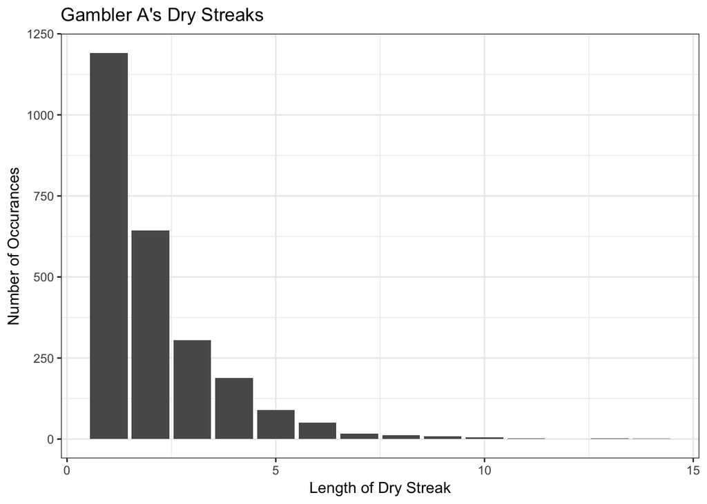

```r
# create a lead dataframe based on the wins dataframe,game number 1 cannot be a dry streak game
ga_wins_lead <- lead(ga_wins)
gb_wins_lead <- lead(gb_wins)
gc_wins_lead <- lead(gc_wins)

# fill in the 10,000 entry with a 0 to make up for the lead
ga_wins_binary <- ga_wins_lead - ga_wins
ga_wins_binary[10000] = 0
gb_wins_binary <- gb_wins_lead - gb_wins
gb_wins_binary[10000] = 0
gc_wins_binary <- gc_wins_lead - gc_wins
gc_wins_binary[10000] = 0

# create an empty dry_count dataframe the same size as the wins binary dataframe
dry_count_a <- 0
dry_count_save_a  <- vector("double", length(ga_wins_binary))
dry_count_b <- 0
dry_count_save_b  <- vector("double", length(gb_wins_binary))
dry_count_c <- 0
dry_count_save_c  <- vector("double", length(gc_wins_binary))

# fill in the wins binary dataframe with 0 or 1 depending on wins
for (i in seq_along(ga_wins_binary)) {
  if (ga_wins_binary[[i]] == FALSE) {
    dry_count_a = dry_count_a + 1
  }
  if (ga_wins_binary[[i]] == TRUE) {
    dry_count_save_a[[i]] = dry_count_a
    dry_count_a = 0
  }
}

# display results for gambler A
dry_tibble_a <- tibble("dry_streak" = dry_count_save_a)

dry_tibble_a <- dry_tibble_a %>%
  filter(dry_streak != 0)

ggplot(dry_tibble_a) +
  geom_bar(aes(dry_streak)) +
  theme_bw() +
  labs(title = "Gambler A's Dry Streaks",
    y = "Number of Occurances",
    x = "Length of Dry Streak"
    )
```

An excellent skew right distribution shows us that in fact a dry streak lasting a single game is by far the most likely outcome (suprise, suprise). Gambler A never experiences a dry streak lasting longer than 14 games.

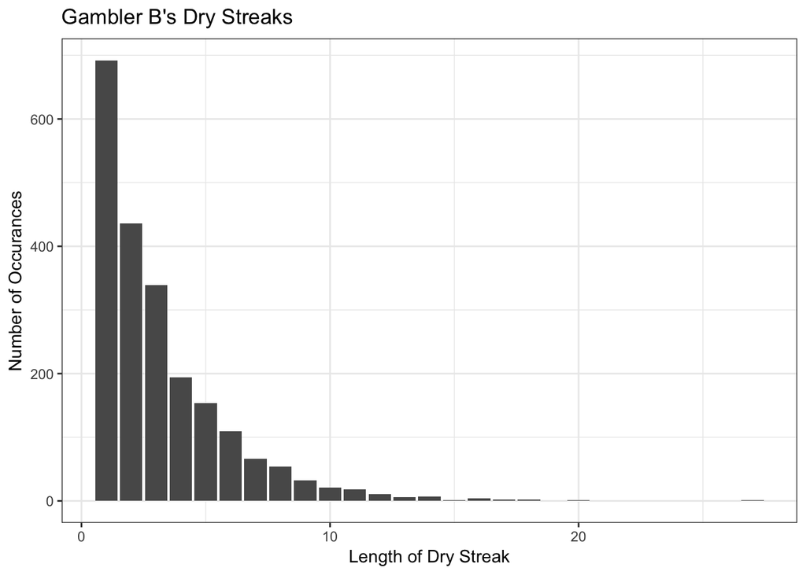

```r
for (i in seq_along(gb_wins_binary)) {
  if (gb_wins_binary[[i]] == FALSE) {
    dry_count_b = dry_count_b + 1
  }
  if (gb_wins_binary[[i]] == TRUE) {
    dry_count_save_b[[i]] = dry_count_b
    dry_count_b = 0
  }
}

dry_tibble_b <- tibble("dry_streak" = dry_count_save_b)
dry_tibble_b <- dry_tibble_b %>%
  filter(dry_streak != 0)

ggplot(dry_tibble_b) +
  geom_bar(aes(dry_streak)) +
  theme_bw() +
  labs(title = "Gambler B's Dry Streaks",
    y = "Number of Occurances",
    x = "Length of Dry Streak"
    )
```

In another beautiful skew right distribution, Gambler B has experienced over 600 single-game dry streaks. The length of potential dry streaks extends all the way to 27 games! That’s awful luck considering Gambler B has a ~32% chance of winning. In fact the odds of gambler B having a 27 game dry streak is .6 ^ 27 or 1.02349 x 10 ^ -6.

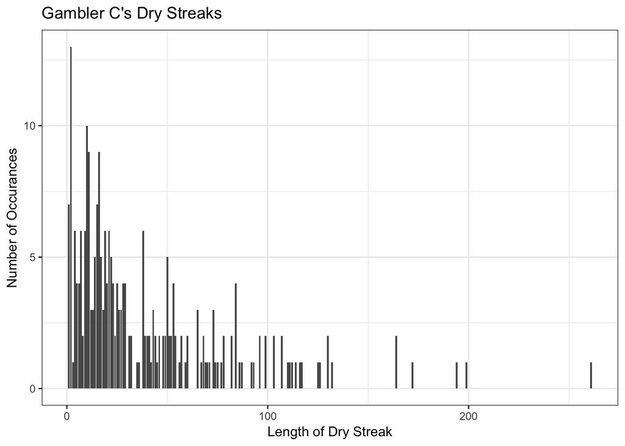

```r
for (i in seq_along(gc_wins_binary)) {
  if (gc_wins_binary[[i]] == FALSE) {
    dry_count_c = dry_count_c + 1
  }
  if (gc_wins_binary[[i]] == TRUE) {
    dry_count_save_c[[i]] = dry_count_c
    dry_count_c = 0
  }
}


dry_tibble_c <- tibble("dry_streak" = dry_count_save_c)
dry_tibble_c <- dry_tibble_c %>%
  filter(dry_streak != 0)

ggplot(dry_tibble_c) +
  geom_bar(aes(dry_streak)) +
  theme_bw() +
  labs(title = "Gambler C's Dry Streaks",
    y = "Number of Occurances",
    x = "Length of Dry Streak"
    )
```

### Summary

As always, Thanks for reading! - Fisher